# False Discovery Rate Control

Author

Scott McCabe

## 1 Why False Discovery Rate Matters

**Why Do We Need FDR Control?**

- In modern data science, we often test hundreds or thousands of hypotheses
- Examples:
  - Genomics: testing gene expression differences
  - A/B testing: evaluating multiple features
  - Social science: multiple survey questions

**The Multiple Testing Problem**

- Suppose we test $m = 1000$ hypotheses
- Each test uses significance level $\alpha = 0.05$
- Even if ALL null hypotheses are true:

$$\text{Expected false positives} = 0.05 \times 1000 = 50$$

- We may incorrectly reject dozens of hypotheses

**False Positives Visualization** - The histogram below shows 1000 p-values generated under the null hypothesis (uniformly distributed between 0 and 1). Even though all nulls are true, we expect about 5% of them (around 50) to be below the 0.05 threshold, leading to false discoveries if we use the standard cutoff without adjustment.

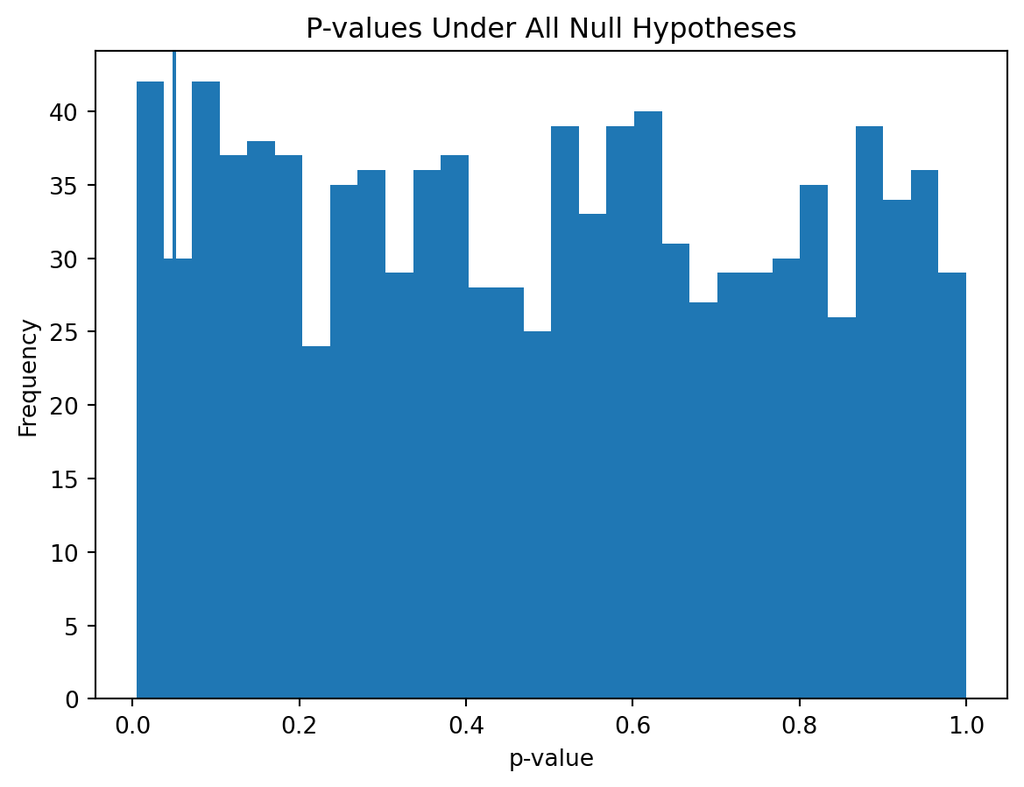

```python
import numpy as np
import matplotlib.pyplot as plt

np.random.seed(42)

m = 1000
pvals = np.random.uniform(0, 1, m)

plt.hist(pvals, bins=30)
plt.axvline(0.05)
plt.title("P-values Under All Null Hypotheses")
plt.xlabel("p-value")
plt.ylabel("Frequency")
plt.show()
```

## 2 Definitions

**Measuring Errors in Multiple Testing**

- When testing many hypotheses, we track:

|  | Null True | Null False |
| --- | --- | --- |
| Reject H₀ | False Positive (V) | True Positive (S) |
| Do Not Reject H₀ | True Negative | False Negative |

- Total rejections:
  $$R = V + S$$

### 2.1 False Discovery Proportion (FDP)

- The proportion of false discoveries among all discoveries:

$$\text{FDP} = \frac{V}{R}$$

- If no rejections (R = 0), define FDP = 0
- Interpretation:
  - FDP = 0 → all discoveries are correct
  - FDP = 0.2 → 20% of discoveries are false

### 2.2 False Discovery Rate (FDR)

- The expected value of FDP:

$$\text{FDR} = \mathbb{E}\left[\frac{V}{R}\right]$$

- This is what we aim to control
- Example:
  - If FDR = 0.05
  - Then on average, 5% of discoveries are false

**Why Expectation?**

- FDP varies from dataset to dataset
- We cannot control it exactly every time
- Instead, we control it **on average across experiments**

This makes FDR practical for real-world data science

**Example**

- Suppose we reject 100 hypotheses:
  - 90 are true discoveries
  - 10 are false discoveries

$$\text{FDP} = \frac{10}{100} = 0.10$$

- Over many experiments:
  - The average FDP is roughly equal to FDR
- FDR does NOT eliminate false positives
- It **controls their proportion**

> “Among all discoveries, most should be correct.”

## 3 Classical Approach vs. Modern Methods

### 3.1 Classical Error Control: FWER

When controlling errors in muliple testing, the traditional approach focuses on avoiding any false positives at all. This is known as controlling the **Family-Wise Error Rate (FWER)**.

- FWER is defined as the probability of making at least one false discovery:
  $$\text{FWER} = P(V \geq 1)$$
- A common method to control FWER is the **Bonferroni correction**,

$$\alpha_{adj} = \frac{\alpha}{m}$$

- A hypothesis is rejected if its p-value satisfies:
  $$p_i \leq \frac{\alpha}{m}$$

For example, if we have 1000 tests and want to maintain an overall $\alpha$ of 0.05, the Bonferroni threshold would be 0.00005, which is extremely strict and often leads to very few discoveries, even when there are true effects present.

**Why FWER is Too Conservative**

- Example:
  - $m = 1000, \alpha = 0.05$
  - Bonferroni threshold = **0.00005**
- Very hard to detect real effects
- While it minimizes false positives, it also leads to many false negatives (missed discoveries)

### 3.2 Modern Approach: False Discovery Rate (FDR)

- Instead of eliminating all errors, control their proportion

$$\text{FDR} = \mathbb{E} \left[ \frac{V}{R} \right]$$

- Goal:
  - Allow some false positives
  - But limit their proportion among discoveries

### 3.3 The Benjamini–Hochberg (BH) Procedure

- The **BH procedure** is the most widely used method for controlling FDR.
- How it works:
  1. Sort p-values from smallest to largest.
  2. Compare each p-value to an increasing threshold:
     $$\frac{i}{m}\alpha$$
  3. Reject all hypotheses up to the largest p-value that satisfies this condition.
- Key idea:
  - The threshold becomes **less strict** as we move through the ranked p-values.
  - This allows more discoveries while still controlling the overall error rate.

**Mindset: FWER vs FDR**

- **FWER mindset:** “I want ZERO false positives.”
- **FDR mindset:** “I can tolerate some false positives, as long as most discoveries are correct.”

**Visual Comparison**

This figure illustrates how the Benjamini–Hochberg (BH) procedure works step by step:

1. **Sort the p-values**
   - The blue curve shows the p-values arranged from smallest to largest (by rank)
2. **Construct the BH threshold**
   - The dashed line represents the BH threshold:
     $$\frac{i}{m}\alpha$$
   - This line increases with rank, making the criterion less strict for larger p-values
3. **Compare p-values to the threshold**
   - For each rank $i$, compare the p-value to the corresponding point on the dashed line
4. **Find the cutoff**
   - Identify the largest rank $i$ where:
     $$p_{(i)} \le \frac{i}{m}\alpha$$
5. **Reject hypotheses**
   - All p-values to the left of this cutoff are rejected
   - These are considered statistically significant discoveries

**Interpretation**

- The blue curve below the dashed line represents rejected hypotheses
- Because the BH threshold increases, it allows more rejections than a fixed cutoff
- In contrast, the Bonferroni line (horizontal) applies the same strict threshold to all tests:
  - Only very small p-values are rejected
  - This leads to fewer discoveries but stronger error control
- The BH procedure adapts to the data: it relaxes the threshold as rank increases, allowing more discoveries while still controlling the expected proportion of false positives.

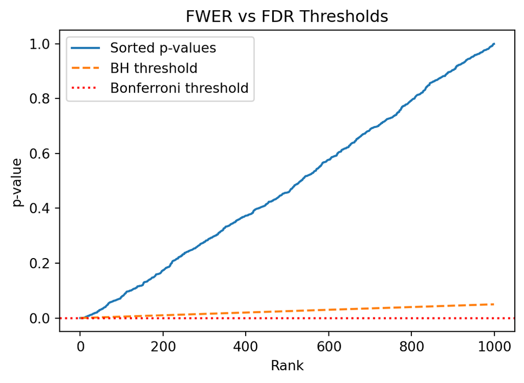

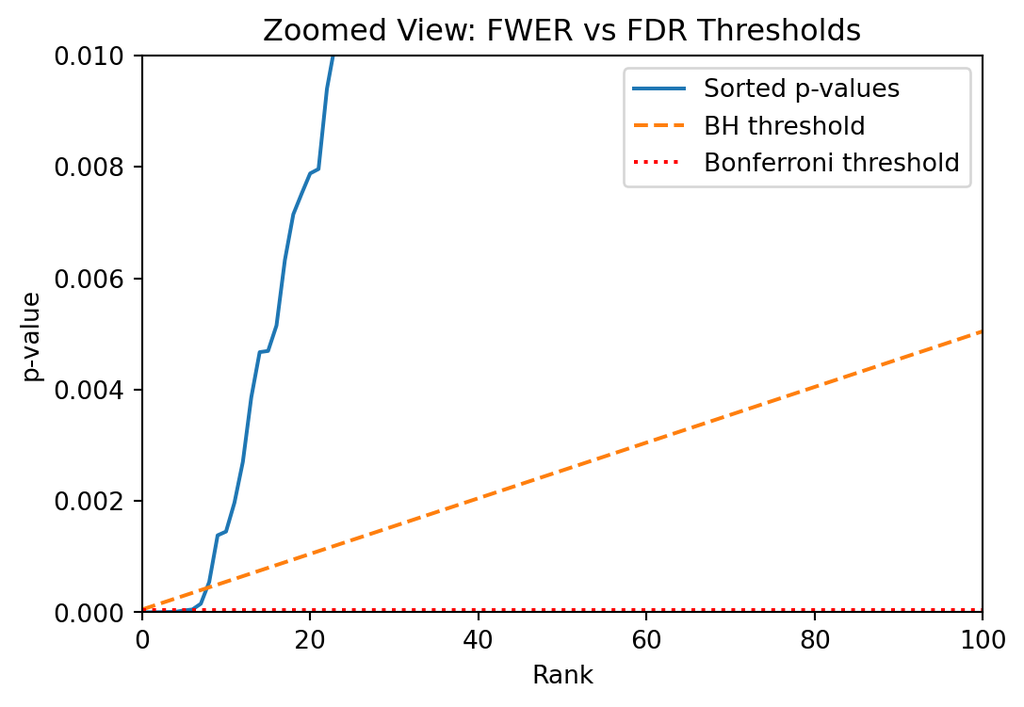

```python
import numpy as np
import matplotlib.pyplot as plt

np.random.seed(0)

m = 1000
pi1 = 0.05  # 5% true signals
m1 = int(m * pi1)
m0 = m - m1

# -----------------------------
# Generate p-values
# -----------------------------
p_null = np.random.uniform(0, 1, m0)
p_signal = np.random.beta(0.3, 1, m1)  # strong signals

pvals = np.sort(np.concatenate([p_null, p_signal]))

# -----------------------------
# Thresholds
# -----------------------------
alpha = 0.05
bonf = alpha / m
bh_line = [(i/m)*alpha for i in range(1, m+1)]

# -----------------------------
# Full Plot
# -----------------------------
plt.figure(figsize=(6,4))
plt.plot(pvals, label="Sorted p-values")
plt.plot(bh_line, '--', label="BH threshold")
plt.axhline(bonf, color='red', linestyle=':', label="Bonferroni threshold")

plt.xlabel("Rank")
plt.ylabel("p-value")
plt.title("FWER vs FDR Thresholds")
plt.legend()
plt.show()

# -----------------------------
# Zoomed Plot
# -----------------------------
plt.figure(figsize=(6,4))
plt.plot(pvals, label="Sorted p-values")
plt.plot(bh_line, '--', label="BH threshold")
plt.axhline(bonf, color='red', linestyle=':', label="Bonferroni threshold")

plt.xlim(0, 100)
plt.ylim(0, 0.01)

plt.xlabel("Rank")
plt.ylabel("p-value")
plt.title("Zoomed View: FWER vs FDR Thresholds")
plt.legend()
plt.show()
```

## 4 The 3 Methods

We compare three methods:

- **FWER (Bonferroni)** – strict error control
- **BH (Benjamini–Hochberg)** – standard FDR method
- **BY (Benjamini–Yekutieli)** – FDR under dependence

### 4.1 1. FWER (Bonferroni)

- Controls:
  $$P(V \geq 1)$$
- Rule:
  $$p_i \leq \frac{\alpha}{m}$$
- Pros:
  - Very safe (almost no false positives)
- Cons:
  - Extremely conservative
  - Low power (misses real signals)

### 4.2 2. BH (Benjamini–Hochberg)

- Controls:
  $$\text{FDR} = \mathbb{E}[V/R]$$
- Procedure:
  1. Sort p-values
  2. Find largest ( k ) such that:
     $$p_{(k)} \leq \frac{k}{m}\alpha$$
- Pros:
  - Good balance of power and error control
  - Widely used
- Cons:
  - Assumes independence (or weak dependence)

### 4.3 3. BY (Benjamini–Yekutieli)

- Modification of BH for **dependent tests**
- Threshold:
  $$p_{(k)} \leq \frac{k}{m} \cdot \frac{\alpha}{\sum_{i=1}^m \frac{1}{i}}$$
- Pros:
  - Valid under arbitrary dependence
- Cons:
  - More conservative than BH
  - Can reduce power significantly

### 4.4 Visual Comparison

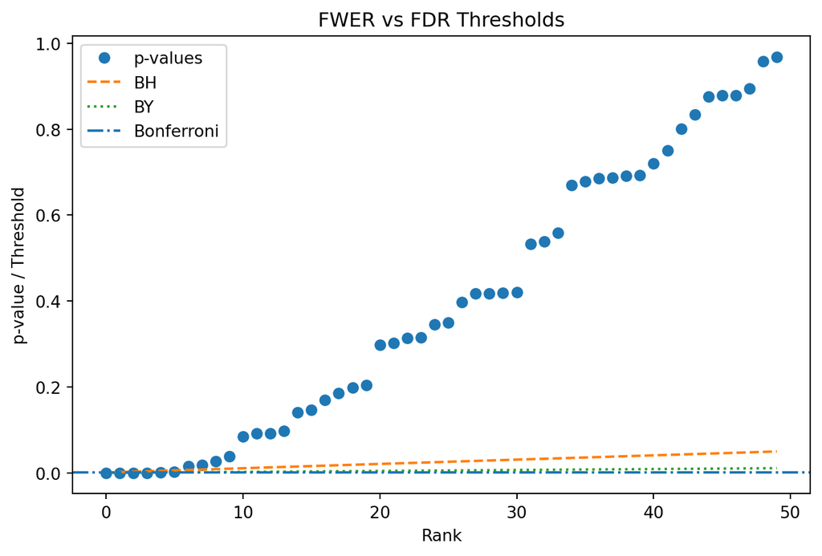

```python
import numpy as np
import matplotlib.pyplot as plt

np.random.seed(1)
m = 50       # smaller number of hypotheses
alpha = 0.05

# 20% true signals
pi1 = 0.2
m1 = int(pi1*m)
m0 = m - m1

# null p-values
p_null = np.random.uniform(0,1,m0)
# strong signals
p_signal = np.random.beta(0.2,1,m1)  # skewed very close to 0

pvals = np.sort(np.concatenate([p_null, p_signal]))

# thresholds
bh = [(i/m)*alpha for i in range(1,m+1)]
by = [(i/m)*alpha / np.sum(1/np.arange(1,m+1)) for i in range(1,m+1)]
bonf = alpha / m

# plot
plt.figure(figsize=(8,5))
plt.plot(pvals, label="p-values", marker='o', linestyle='')
plt.plot(bh, '--', label="BH")
plt.plot(by, ':', label="BY")
plt.axhline(bonf, linestyle='-.', label="Bonferroni")
plt.xlabel("Rank")
plt.ylabel("p-value / Threshold")
plt.title("FWER vs FDR Thresholds")
plt.legend()
plt.show()
```

## 5 Simulation

### 5.1 Simulation: Comparing Methods

- Compare **FWER, BH, and BY**
- Evaluate:
  - Number of rejections
  - False Discovery Rate (FDR)
  - Power (true positives)

### 5.2 Simulation Setup

Data generation and method application are repeated across multiple simulations to assess average performance.

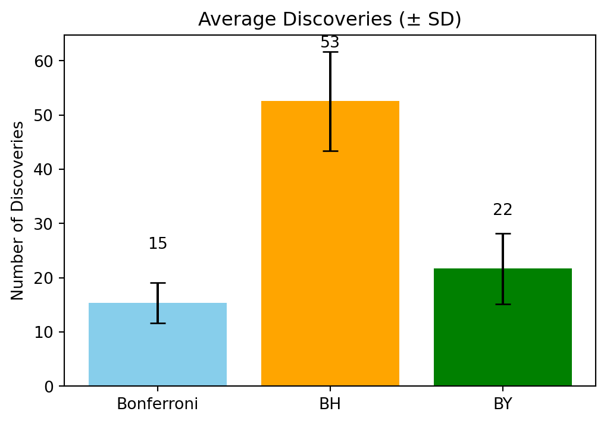

```
Interpretation:
BH discovers the most signals, while Bonferroni is very conservative.
BY is in between but closer to Bonferroni.
```

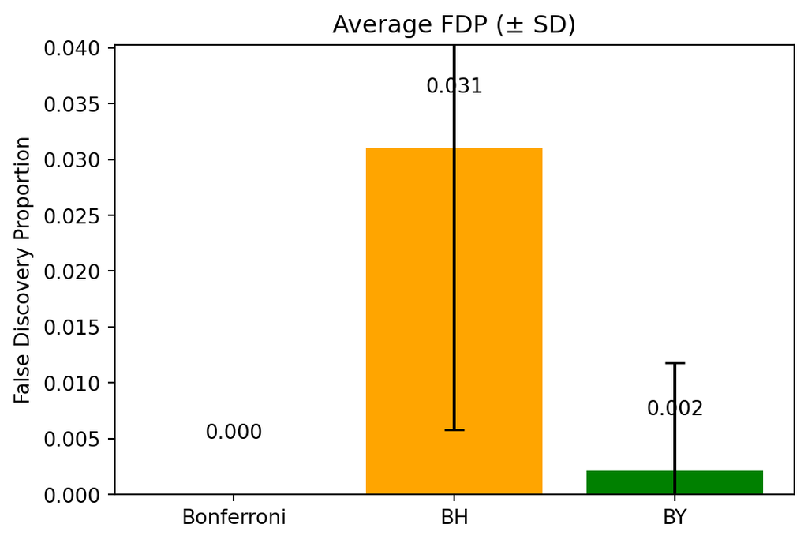

```
Interpretation:
All methods control false discoveries well.
Bonferroni and BY have very low FDP.
BH has a slightly higher but still acceptable FDP.
```

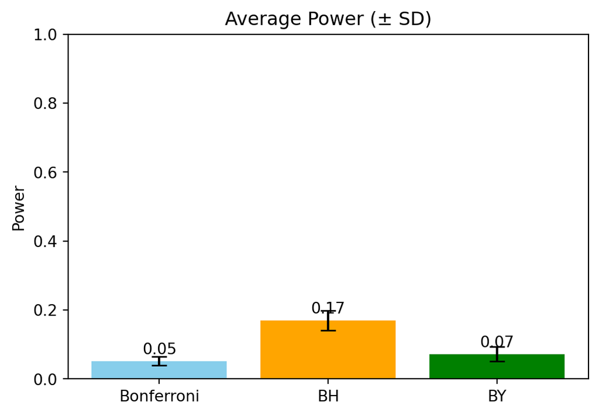

```
Interpretation:
BH has the highest power, meaning it detects the most true signals.
BY has lower power than BH due to its conservativeness under dependence.
Bonferroni has the lowest power, missing many true discoveries.
```

```python
import numpy as np
import matplotlib.pyplot as plt
from statsmodels.stats.multitest import multipletests

# -------------------------------
# Simulation parameters
# -------------------------------
np.random.seed(123)

m = 1000
pi1 = 0.3
m1 = int(pi1 * m)
m0 = m - m1

alpha = 0.05
n_sim = 100  # number of simulations

methods = {
    "Bonferroni": "bonferroni",
    "BH": "fdr_bh",
    "BY": "fdr_by"
}

# Store results across simulations
R_all = {name: [] for name in methods}
fdp_all = {name: [] for name in methods}
power_all = {name: [] for name in methods}

# -------------------------------
# Run simulations
# -------------------------------
for sim in range(n_sim):

    # Generate data each time
    p_null = np.random.uniform(0, 1, m0)
    p_signal = np.random.beta(0.3, 1, m1)

    pvals = np.concatenate([p_null, p_signal])
    truth = np.array([0]*m0 + [1]*m1)

    for name, method in methods.items():
        reject, _, _, _ = multipletests(pvals, alpha=alpha, method=method)

        R = reject.sum()
        V = ((reject == 1) & (truth == 0)).sum()
        S = ((reject == 1) & (truth == 1)).sum()

        fdp = V / R if R > 0 else 0
        power = S / m1

        R_all[name].append(R)
        fdp_all[name].append(fdp)
        power_all[name].append(power)

# -------------------------------
# Compute averages and std devs
# -------------------------------
names = list(methods.keys())
x = np.arange(len(names))

R_mean = [np.mean(R_all[n]) for n in names]
R_std  = [np.std(R_all[n]) for n in names]

fdp_mean = [np.mean(fdp_all[n]) for n in names]
fdp_std  = [np.std(fdp_all[n]) for n in names]

power_mean = [np.mean(power_all[n]) for n in names]
power_std  = [np.std(power_all[n]) for n in names]

colors = ['skyblue', 'orange', 'green']

# -------------------------------
# Number of Discoveries
# -------------------------------
plt.figure(figsize=(6,4))
bars = plt.bar(x, R_mean, yerr=R_std, capsize=5, color=colors)
plt.xticks(x, names)
plt.ylabel("Number of Discoveries")
plt.title("Average Discoveries (± SD)")

for bar, val in zip(bars, R_mean):
    plt.text(bar.get_x() + bar.get_width()/2, val + 10, f"{val:.0f}", ha='center')

plt.show()

print("Interpretation:")
print("BH discovers the most signals, while Bonferroni is very conservative.")
print("BY is in between but closer to Bonferroni.")

# -------------------------------
# FDP
# -------------------------------
plt.figure(figsize=(6,4))
bars = plt.bar(x, fdp_mean, yerr=fdp_std, capsize=5, color=colors)
plt.xticks(x, names)
plt.ylabel("False Discovery Proportion")
plt.title("Average FDP (± SD)")
plt.ylim(0, max(fdp_mean)*1.3)

for bar, val in zip(bars, fdp_mean):
    plt.text(bar.get_x() + bar.get_width()/2, val + 0.005, f"{val:.3f}", ha='center')

plt.show()

print("Interpretation:")
print("All methods control false discoveries well.")
print("Bonferroni and BY have very low FDP.")
print("BH has a slightly higher but still acceptable FDP.")

# -------------------------------
# Power
# -------------------------------
plt.figure(figsize=(6,4))
bars = plt.bar(x, power_mean, yerr=power_std, capsize=5, color=colors)
plt.xticks(x, names)
plt.ylabel("Power")
plt.title("Average Power (± SD)")
plt.ylim(0,1)

for bar, val in zip(bars, power_mean):
    plt.text(bar.get_x() + bar.get_width()/2, val + 0.02, f"{val:.2f}", ha='center')

plt.show()

print("Interpretation:")
print("BH has the highest power, meaning it detects the most true signals.")
print("BY has lower power than BH due to its conservativeness under dependence.")
print("Bonferroni has the lowest power, missing many true discoveries.")
```

## 6 Key Takeaways

1. **Multiple testing is tricky**
   - Testing many hypotheses increases the chance of false positives.
   - Traditional FWER control (Bonferroni) is too strict for large-scale testing.
2. **FDR vs FWER**
   - FWER: strict, very few false positives, low power.
   - FDR: controls the expected proportion of false discoveries, higher power.
3. **Choosing a method**

| Method | When to Use |
| --- | --- |
| Bonferroni (FWER) | Very strict control, few tests |
| BH (Benjamini-Hochberg) | Default FDR control, independent/weakly dependent tests |
| BY (Benjamini-Yekutieli) | Dependent tests |

4. **Simulation confirms intuition**
   - BH discovers more true signals but has a slightly higher FDP.
   - BY is more conservative than BH, leading to fewer discoveries but lower FDP.
   - Bonferroni is the most conservative, with the fewest discoveries and lowest FDP.
5. **Practical Use in Data Science**
   - No single “best” method — choose based on signal strength, test dependence, and desired strictness
   - FDR control methods like BH are often a good starting point for large-scale testing in data science.

## 7 References

Efron, B. (2010). False discovery rate control. In Large‑scale inference: Empirical bayes methods for estimation, testing, and prediction (pp. 46–69). Cambridge University Press. https: //utstat.toronto.edu/reid/sta2212s/2021/EfronLSIChapter4.pdf

Genovese, C. R. (2004). A tutorial on false discovery control. Technical report, Carnegie Mellon University.

Public Health, C. U. M. S. of. (n.d.). False discovery rate. Web page. https://www.publichealth. columbia.edu/research/population-health-methods/false-discovery-rate 15